# Normalisation of ATAC-seq data

29 March 2019

We have QCed the ATAC-seq data, retaining 50 of 75 samples.

```r
## metadata
meta <- read.table(paste0(dir, "ATAC-seq/data/metadata_ATACseq.tsv"), stringsAsFactors = FALSE, header = TRUE)
meta <- meta[meta$QCpass==1,]

## data
bam.files <- paste0(meta$sample, ".noDUPs.GQ.bam")
```

### Defining a peak set

We have called peaks using as input all samples merged together.

```r
peakSet <- read.table(paste0(dir, "ATAC-seq/peaks/allGQsamples_peaks.broadPeak"))
peakSet <- GRanges(peakSet$V1, IRanges(peakSet$V2, peakSet$V3), fc=peakSet$V7, fdr=peakSet$V9)

# remove peaks in blacklisted regions
blacklist <- readRDS(paste0(dir, "ATAC-seq/data/mm10-blacklist.v2.Rds"))
remove <- unique(queryHits(findOverlaps(peakSet, blacklist)))
peakSet <- peakSet[-remove]

# save fo future use
saveRDS(peakSet, paste0(dir, "ATAC-seq/results/03_peakSet_full.Rds"))
```

This resulted in 131743 called peaks, which can be used as a common peak-set for all samples.

We count the number of fragments mapped to these regions in each sample, to get a uniform measure of fraction of reads in peaks (FRiP) for all samples. Before, each sample had its own set of peaks, making their FRiPs non-comparable.

```r
param <- readParam(discard=blacklist, restrict=paste0("chr", c(1:19, "X")), pe="both", dedup=FALSE, BPPARAM=MulticoreParam(workers=12))
peakCounts <- regionCounts(paste0(dir, "ATAC-seq/data/BWA/", bam.files), peakSet, param = param)
saveRDS(peakCounts, paste0(dir, "ATAC-seq/results/03_peakCounts_all.Rds"))

meta$readsInPeakSet <- colSums(assay(peakCounts))
write.table(meta, paste0(dir, "ATAC-seq/data/metadata_ATACseq_GQ.tsv"), quote = FALSE, sep="\t", row.names = FALSE)
```

### Normalisation

The first thing we need to do is to normalise the data to remove technical biases and have comparable samples across our conditions of interest. For this, we will use methods implemented in the `csaw` package.

Besides sequencing depth differences, technical biases include composition and efficiency biases. Composition biases arise when there are significant differences in the number or nature of regions being profiled in different samples; in our case, these biases could arise if certain stages have a significantly different set of peaks compared to others. Efficiency biases instead relate to the efficiency of the reactions producing the data, i.e. the tagmentation of the samples.

#### Composition biases

Composition biases manifest as systematic differences in the fragment counts across the genome. This is because if a sample has peaks absent in other samples, the allocation of reads to these extra peaks results in a depletion of reads everywhere else.

Thus, to assess if there are any composition biases in our data, we count the number of sequencing fragments mapped across 10kb bins tiling the whole genome. These bins should be large enough to provide stable counts and detect any systematic biases. We assume the majority of the genome is not differentially accessible between samples, and thus should have equivalent counts (after accounting for library size).

```r
background <- windowCounts(paste0(dir, "ATAC-seq/data/BWA/", bam.files), bin=TRUE, width=10000, param=param)
saveRDS(background, paste0(dir, "ATAC-seq/results/03_backgroundCounts_10kbBins.Rds"))
```

`csaw` uses `edgeR` TMM method to calculate size factors based on the bin counts. We observe that most size factors are close to 1, which suggests that we do not have significant composition biases in the data.

```r
sf.comp <- normFactors(background, se.out=FALSE)
summary(sf.comp)
```

```
##    Min. 1st Qu.  Median    Mean 3rd Qu.    Max.
##  0.7332  0.9685  1.0291  1.0026  1.0445  1.0800
```

#### Efficiency biases

Next, we check for efficiency biases instead. Given that we have seen large variation in the FRiP of the different samples, it is likely that the efficiency of the tagmentation, or perhaps the quality of the chromatin, are biasing the data.

To compute efficiency biases we instead focus on the counts of our regions of enrichment (peaks). Again, if the reaction is much more efficient in one sample, it will generate higher enrichment of reads in peaks compared to background, and it will manifest as a systematic increase in the counts.

To test for differential accessibility we will use sliding windows across the genome, to be able to capture shape changes, as well as overall peak abundance changes. Thus, we start by computing the fragment counts on 150bp windows sliding 50bp, across the whole genome. Then, we retain only the windows that overlap peaks.

```r
winCounts <- windowCounts(paste0(dir, "ATAC-seq/data/BWA/", bam.files), width=150, spacing=50, filter=75, param = param)
saveRDS(winCounts, paste0(dir, "ATAC-seq/results/03_windowCounts_150width_50space_75filter.Rds"))

keep.overlap <- overlapsAny(rowRanges(winCounts), peakSet)
summary(keep.overlap)
```

```
##     Mode    FALSE     TRUE
##  logical 30173825  3177316
```

Since we used all samples to call peaks, we have increased power greatly, allowing calling of very low enrichment regions on a per sample basis. Thus, besides restricting the analysis to windows within peaks, we also need to filter out those that are of too low abundance, since we won’t have power to do any differential testing on them.

A cutoff of 4 average counts per window retains a similar number of windows to those that overlap peaks. And the two filters agree quite well.

```r
abundances <- aveLogCPM(asDGEList(winCounts)) ## this are mean abundance corrected for library size
# plot(density(abundances))
keep.minCount <- abundances > aveLogCPM(4, lib.size = mean(winCounts$totals))
# summary(keep.minCount)

table(keep.overlap, keep.minCount)
```

```
##             keep.minCount
## keep.overlap    FALSE     TRUE
##        FALSE 29296721   877104
##        TRUE    793721  2383595
```

So we retain only windows within peaks that also pass the minimum count filter.

```r
keep <- keep.overlap & keep.minCount

filtered.data <- winCounts[keep,]
```

Next, we use this subset of windows to compute size factors with the TMM method. In this case, the size factors differ significantly from 1, supporting the presence of strong efficiency biases that need to be corrected before downstream analyses can proceed.

```r
sf.eff <- normFactors(filtered.data, se.out = FALSE)
summary(sf.eff)
```

```
##    Min. 1st Qu.  Median    Mean 3rd Qu.    Max.
##  0.6047  0.7723  0.9412  1.0490  1.3005  2.2384
```

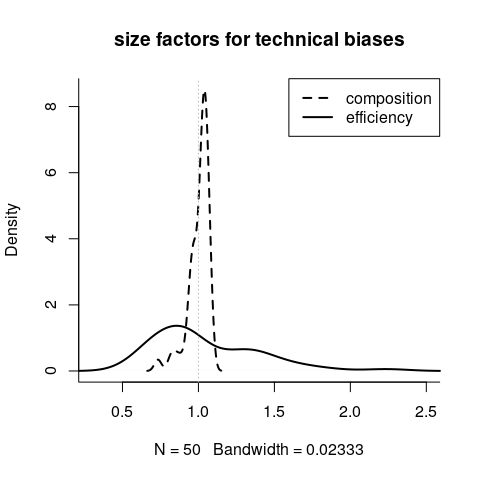

```r
plot(density(sf.comp), xlim=c(0.3,2.5), lty=2, lwd=2, bty="l", main="size factors for technical biases")
lines(density(sf.eff), lwd=2)
abline(v=1, lty=3, col="grey")
legend("topright", legend = c("composition", "efficiency"), lty=c(2,1), lwd=2)
```

#### Assessing technical biases

One way of assessing the technical biases captured by the size factors computed above is via MA plots, which plot the average abundance across samples (A) of each region in the `x-axis` versus the log fold-change between a pair of samples (M) in the `y-axis`. We do this with the 10kb bin counts to have large enough counts to be able to observe systematic biases, normalised for library size.

The majority of the bins, observed as the dark blue concentration of data points, represent background noise and these have low mean abundance levels; shifts in their fold-change evidence composition biases and thus the composition size factors pass through the centre of this cloud (dashed line). Most of the time, the dashed line overlaps the red line at M=0, indicating no bias.

There are much fewer bins with much higher mean abundance that represent true enrichment sites (peaks). In this case, deviation of the fold-changes evidence efficiency biases, and the corresponding size factors (solid line) intersect this much smaller portion of the data cloud.

```r
adj.counts <- cpm(asDGEList(background), log=TRUE)

par(mfrow=c(1, 4), mar=c(5, 4, 2, 1.5))
for (i in 2:ncol(adj.counts)) {
  cur.x <- adj.counts[,1]
  cur.y <- adj.counts[,i]
  smoothScatter(x=(cur.x+cur.y)/2, y=cur.x-cur.y, xlab="A", ylab="M", main=paste("1 vs", i))
  abline(h=0, col="red", lwd=2)
  abline(h=c(log2(sf.comp[1]/sf.comp[i]), log2(sf.eff[1]/sf.eff[i])), lty=c(2,1))
}
```

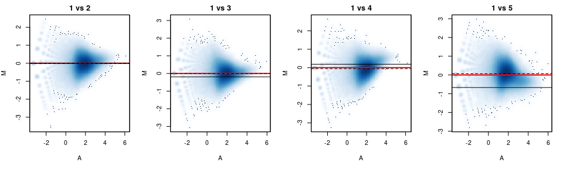

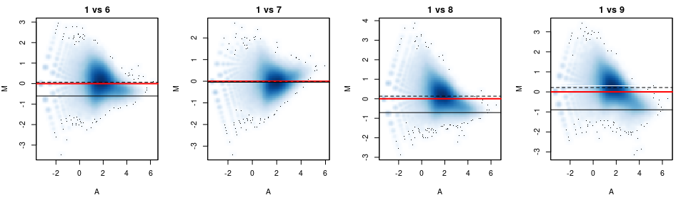

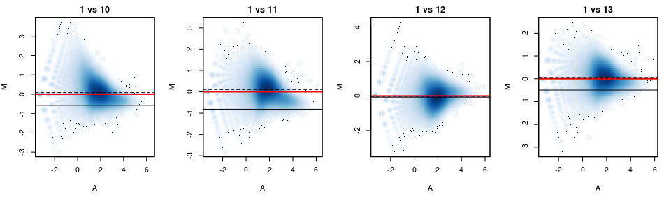

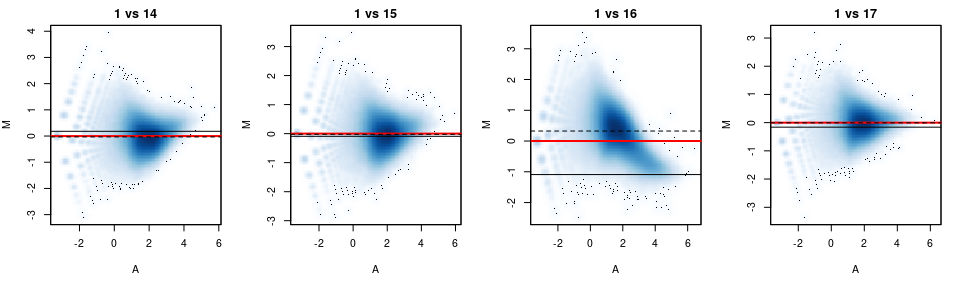

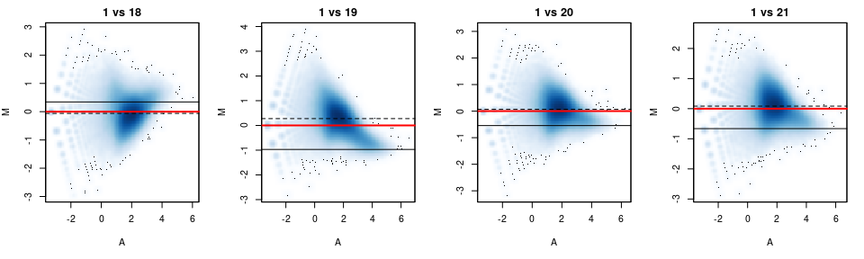

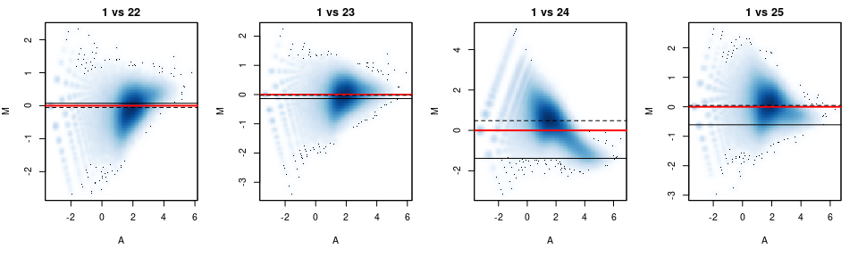

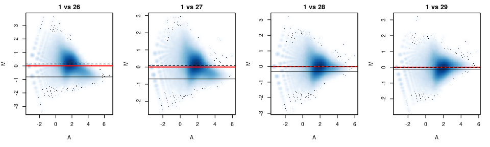

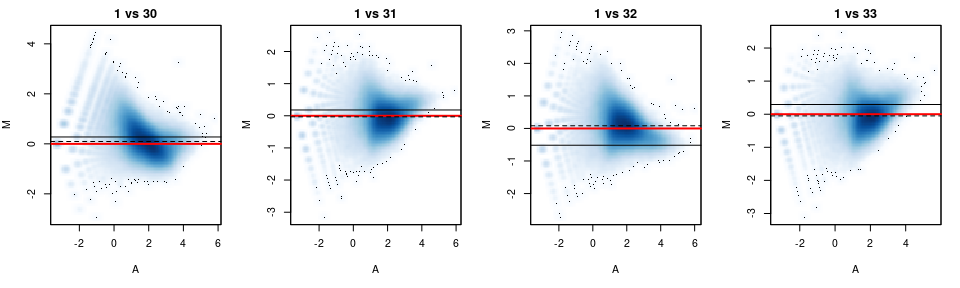

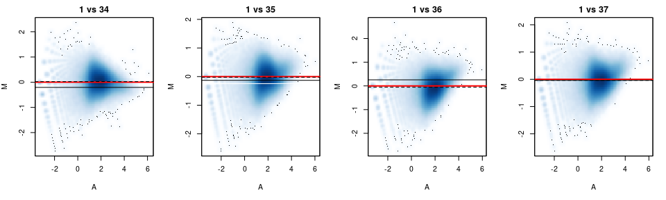

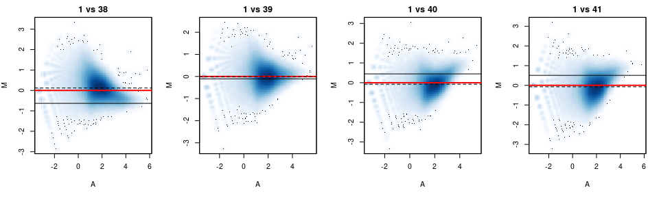

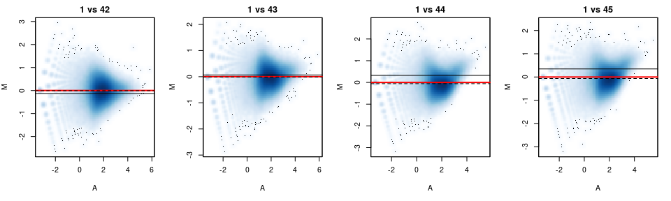

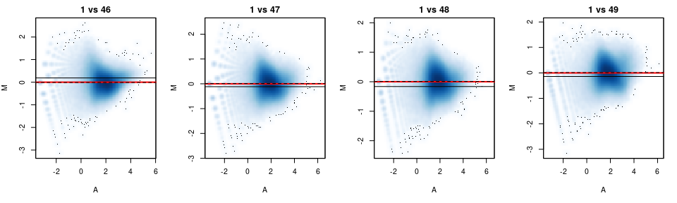

[1 more figures not shown]

Importantly, in many cases we observe that the fold-change of high abundance bins changes concurrently with the change in mean abundance. This implies differences in the technical biases depending on the overall enrichment of the regions being profiled, and thus a single size factor would not correct the effect.

Instead, it is more appropriate to use a *trended normalisation* strategy, where a different scaling factor is computed for each window, depending on its mean abundance. This is achieved using a *loess*-based estimation of the trend.

```r
## each offset represents the log-transformed scaling factor that needs to be applied to the corresponding entry of the count matrix for its normalization
filtered.data <- normOffsets(filtered.data, type="loess", se.out=TRUE)
sf.trended <- assay(filtered.data, "offset")

## save for future use
saveRDS(filtered.data, file=paste0(dir, "ATAC-seq/results/03_windowCounts_filteredWindows.Rds"))
saveRDS(sf.trended, paste0(dir, "ATAC-seq/results/03_trendedNorm_sizeFactors.Rds"))
```

And we can check that the normalisation works by computing MA plots with the corrected data. Now the data is centred around M=0 and no trended effects are present.

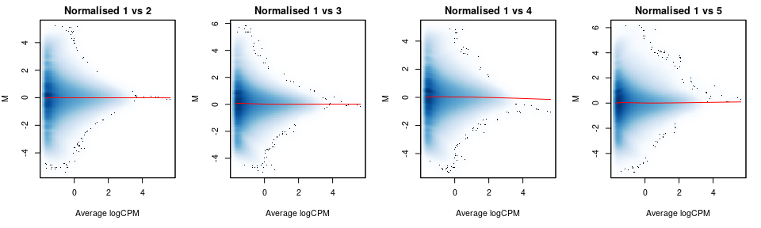

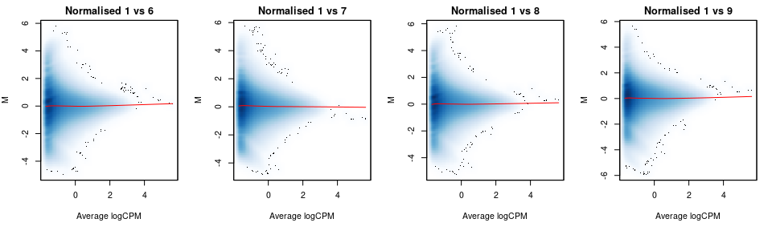

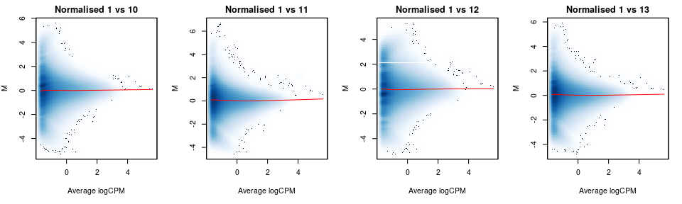

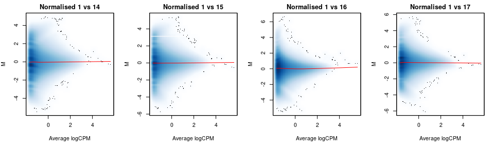

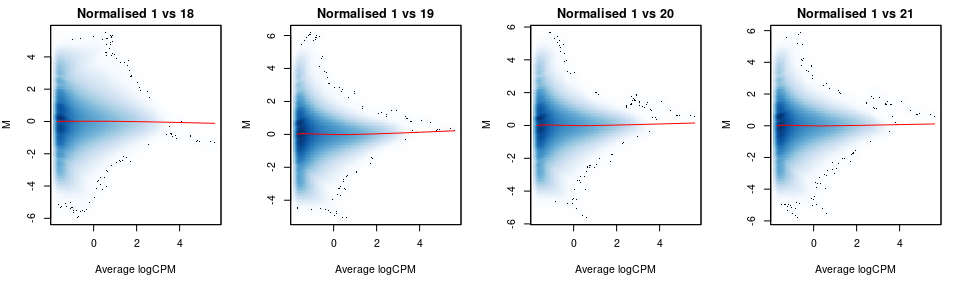

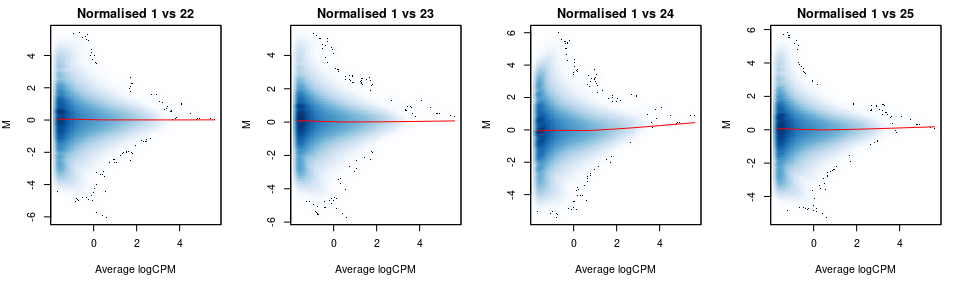

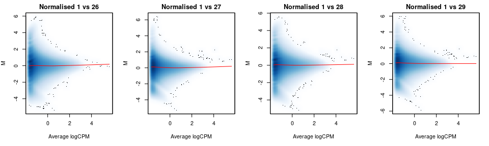

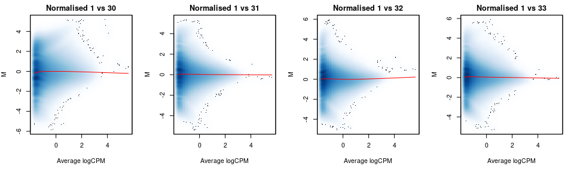

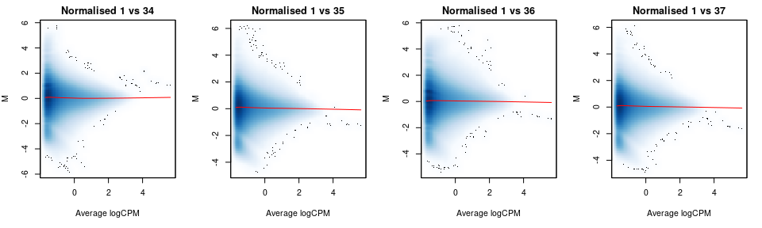

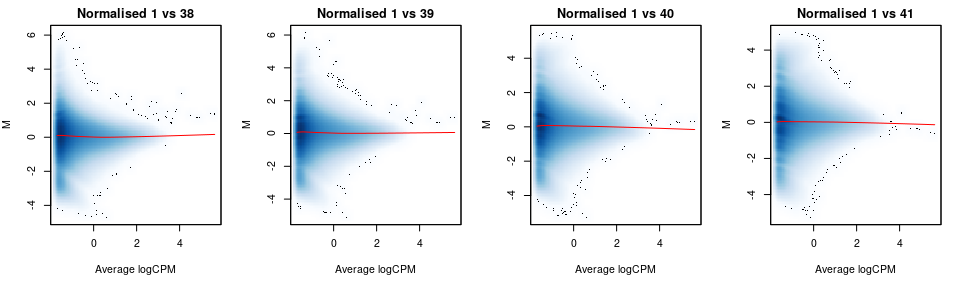

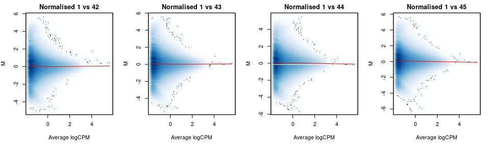

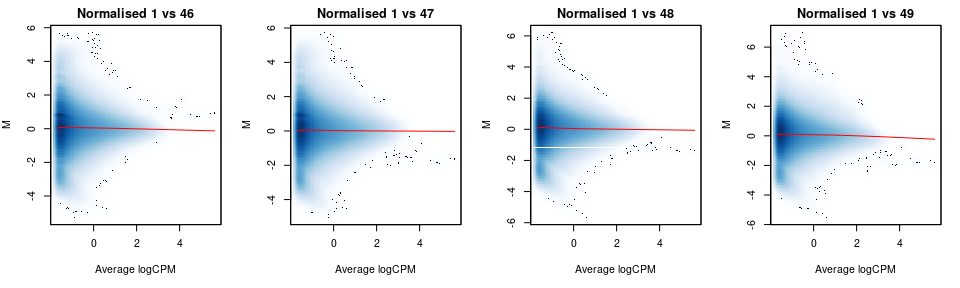

[1 more figures not shown]

```r
adjc <- log2(assay(filtered.data)+0.5)
abval <- aveLogCPM(asDGEList(filtered.data))
o <- order(abval)

re.adjc <- adjc - sf.trended/log(2)

par(mfrow=c(1, 4), mar=c(5, 4, 2, 1.5))
for(i in 2:ncol(re.adjc)){
  mval <- re.adjc[,1]-re.adjc[,i]
  fit <- loessFit(x=abval, y=mval)
  smoothScatter(abval, mval, ylab="M", xlab="Average logCPM", main=paste("Normalised 1 vs",i))
  lines(abval[o], fit$fitted[o], col="red")
}
```

#### Assessing successful normalisation

If normalisation has indeed removed technical biases, these should not account for a significant amount of the data’s variability, and certainly not more than the variation expected from our variables of interest. To check this we use PCA, based on the 5,000 most variable windows. Ideally, samples would then cluster based on our biological variables of interest. But we can also check whether they are grouping by technical effects.

Below is the PCA plot with points (samples) coloured by their stage or date of collection. We observe a bit of grouping by stage (mainly stage35), and a bit of grouping by batch, but nothing particularly clear.

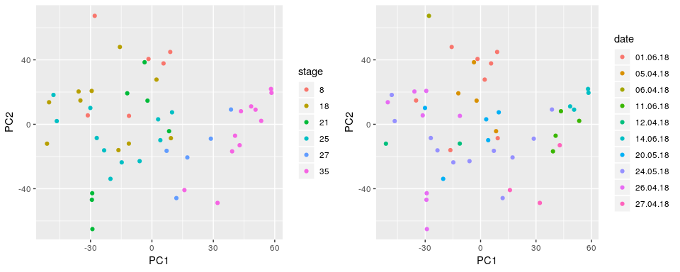

```r
vars <- rowVars(as.matrix(re.adjc))
tmp <- re.adjc[order(vars, decreasing=TRUE)[1:5000],]
pca <- prcomp(t(tmp))
df <- cbind(pca$x, meta)

plots <- list()
plots[[1]] <- ggplot(df, aes(PC1, PC2)) + geom_point(aes(colour=as.factor(df$stage))) + labs(colour="stage")
plots[[2]] <- ggplot(df, aes(PC1, PC2)) + geom_point(aes(colour=df$date)) + labs(colour="date")
multiplot(plotlist = plots, cols=2)
```

If we instead colour points by their library size or FRiP, we observe clear correlations.

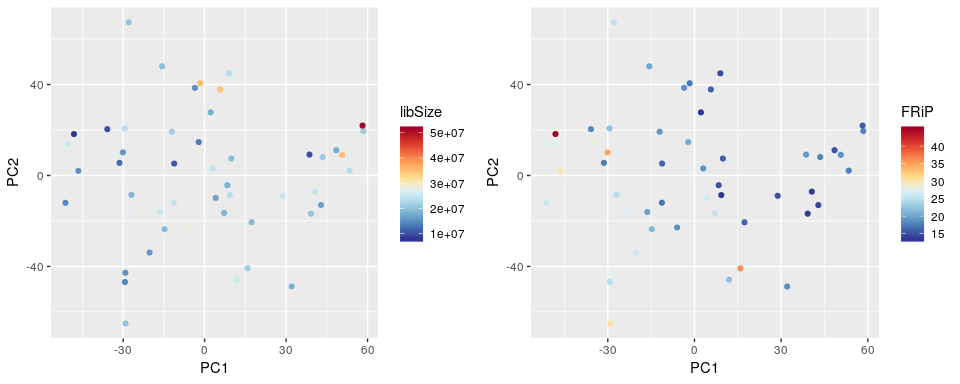

```r
plots[[1]] <- ggplot(df, aes(PC1, PC2)) + geom_point(aes(colour=df$goodQuality)) + scale_color_gradientn(colors=rev(brewer.pal(n=10,"RdYlBu"))) + labs(colour="libSize")
plots[[2]] <- ggplot(df, aes(PC1, PC2)) + geom_point(aes(colour=df$readsInPeakSet/df$goodQuality*100)) + scale_color_gradientn(colors=rev(brewer.pal(n=10,"RdYlBu"))) + labs(colour="FRiP")
multiplot(plotlist = plots, cols=2)
```

```r
# cor(df$PC1, df$readsInPeakSet/df$goodQuality*100) # -0.59
# cor(df$PC1, df$goodQuality) # 0.34
```

The correlation with FRiP is particularly strong.

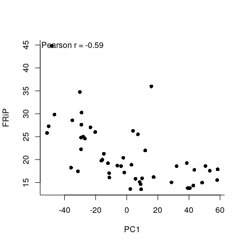

```r
plot(df$PC1, df$readsInPeakSet/df$goodQuality*100, xlab="PC1", ylab="FRiP", bty="l", pch=16)
mtext(side=3, line=-1, text = paste0("Pearson r = ", round(cor(df$PC1, df$readsInPeakSet/df$goodQuality*100),2)), at=-35)
```

This suggests that the normalisation hasn’t successfully removed efficiency biases.

### Removing unwanted technical variation

#### SVA

In order to remove the remaining technical variation in the data after the trended normalisation we can use surrogate variable analysis (sva) to infer the systematic effects in the data, that are not due to our conditions of interest.

We use the `sva` function from the `sva` package. The input data is the normalised counts. The algorithm identifies 1 surrogate variable (SV).

```r
## design matrix
meta$group <- factor(paste(meta$stage, meta$somite, sep="."))
design <- model.matrix(~0+group, meta)
colnames(design) <- paste0("stage",levels(meta$group))

## SVA
n.sv = num.sv(re.adjc, design, method="leek", seed=174)
mod0 = model.matrix(~1, data=meta)
svobj = sva(re.adjc, design, mod0, n.sv = n.sv)
```

```
## Number of significant surrogate variables is:  1
## Iteration (out of 5 ):1  2  3  4  5
```

```r
write.table(svobj$sv, paste0(dir, "ATAC-seq/results/03_svs_trendNormData.tab"), quote = FALSE, sep="\t", row.names = FALSE, col.names = FALSE)
```

This SV is strongly correlated with the FRiP, and thus should remove the effects observed above.

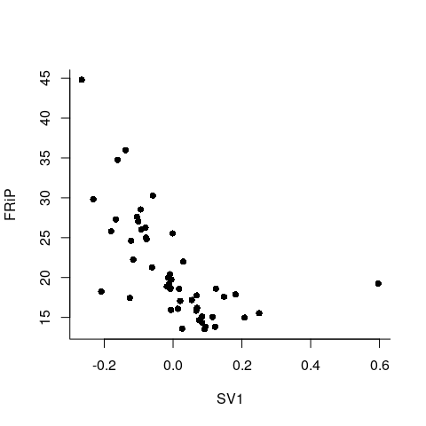

```r
plot(svobj$sv[,1], meta$readsInPeakSet/meta$goodQuality*100, xlab="SV1", ylab="FRiP", pch=16, bty="l")
```

```r
# cor(svobj$sv[,1], meta$readsInPeakSet/meta$goodQuality*100) # -0.63
# cor(svobj$sv[,1], meta$goodQuality) # 0.27
```

We can regress out this SV and redo the PCA with the corrected data. In this case, samples separate a bit better by stage, and there is no correlation with FRiP in the first two components.

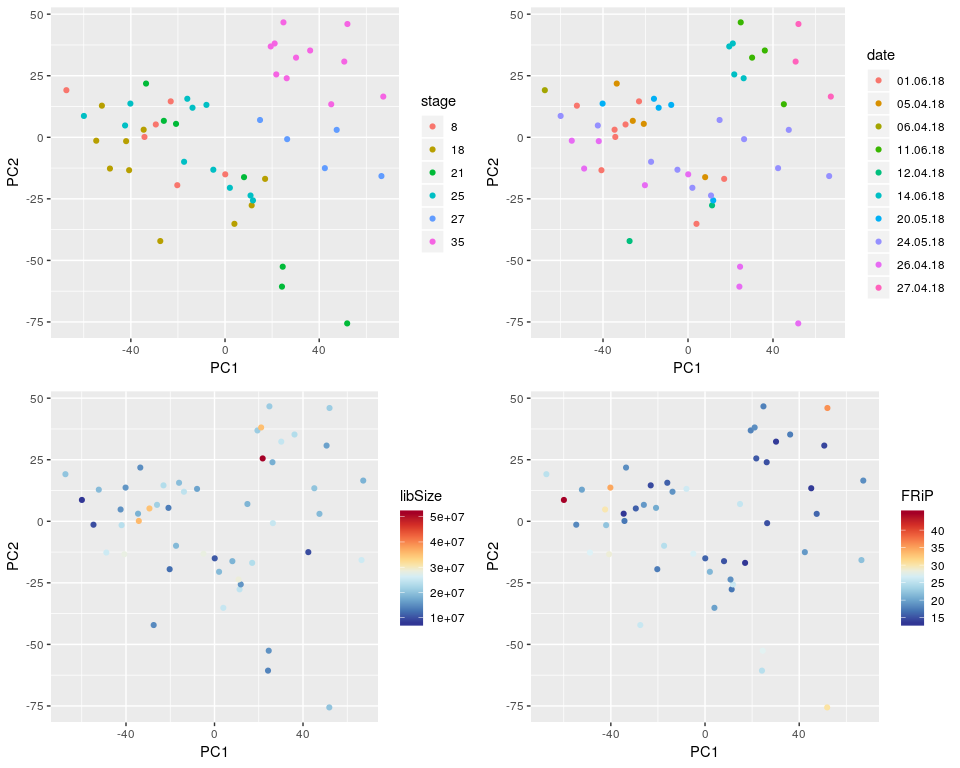

```r
norm.counts.corr <- removeBatchEffect(re.adjc, design = design, covariates = svobj$sv)

vars <- rowVars(norm.counts.corr)
tmp <- norm.counts.corr[order(vars, decreasing=TRUE)[1:5000],]
pca <- prcomp(t(tmp))
df <- cbind(pca$x, meta)

plots <- list()
plots[[1]] <- ggplot(df, aes(PC1, PC2)) + geom_point(aes(colour=as.factor(df$stage))) + labs(colour="stage")
plots[[2]] <- ggplot(df, aes(PC1, PC2)) + geom_point(aes(colour=df$date)) + labs(colour="date")

plots[[3]] <- ggplot(df, aes(PC1, PC2)) + geom_point(aes(colour=df$goodQuality)) + scale_color_gradientn(colors=rev(brewer.pal(n=10,"RdYlBu"))) + labs(colour="libSize")
plots[[4]] <- ggplot(df, aes(PC1, PC2)) + geom_point(aes(colour=df$readsInPeakSet/df$goodQuality*100)) + scale_color_gradientn(colors=rev(brewer.pal(n=10,"RdYlBu"))) + labs(colour="FRiP")
multiplot(plotlist = plots, cols=2)
```

#### PCA

An alternative approach is to use PCA on the residuals after fitting the model including our biological effects and remove the amount of variation that is above that expected by chance.

So we fit a model including the design considering stage and somite, and apply PCA on the residuals of the fit. We then use the `parallelPCA` function from `scran` to estimate the number of PCs to keep.

```r
## insead of using SVA, use PCA to identify the variation on the residuals after fitting the design of interest
fit <- lmFit(re.adjc, design)
res <- residuals(fit, re.adjc)

# pca
pcs <- prcomp(t(res))
write.table(pcs$x, paste0(dir, "ATAC-seq/results/03_pcs_residuals.tab"), quote = FALSE, sep="\t", row.names = FALSE, col.names = FALSE)
```

Regressing out 18 PCs cleans the data very nicely. Now samples cluster by stage very well.

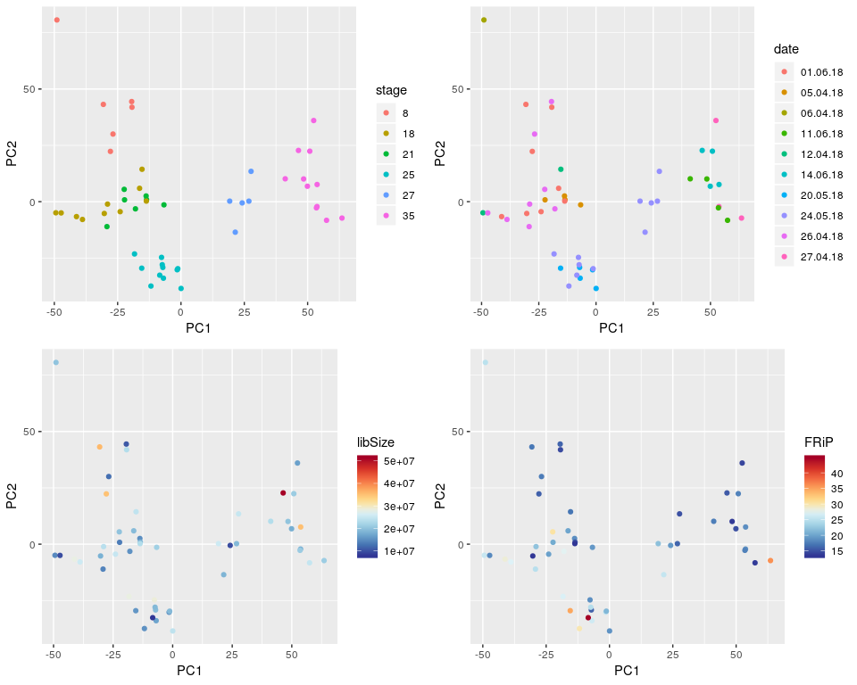

```r
# plugging 're.adjc' into scran::parallelPCA() returns 18
norm.counts.corr.pca <- removeBatchEffect(re.adjc, design=design, covariates = pcs$x[,1:18])

vars <- rowVars(norm.counts.corr.pca)
tmp <- norm.counts.corr.pca[order(vars, decreasing=TRUE)[1:5000],]
pca <- prcomp(t(tmp))
df <- cbind(pca$x, meta)

plots <- list()

plots[[1]] <- ggplot(df, aes(PC1, PC2)) + geom_point(aes(colour=as.factor(df$stage))) + labs(colour="stage")
plots[[2]] <- ggplot(df, aes(PC1, PC2)) + geom_point(aes(colour=df$date)) + labs(colour="date")
plots[[3]] <- ggplot(df, aes(PC1, PC2)) + geom_point(aes(colour=df$goodQuality)) + scale_color_gradientn(colors=rev(brewer.pal(n=10,"RdYlBu"))) + labs(colour="libSize")
plots[[4]] <- ggplot(df, aes(PC1, PC2)) + geom_point(aes(colour=df$readsInPeakSet/df$goodQuality*100)) + scale_color_gradientn(colors=rev(brewer.pal(n=10,"RdYlBu"))) + labs(colour="FRiP")
multiplot(plotlist = plots, cols=2)
```

This strategy should increase our power to detect differentially accessible regions based on the design including stage and somite. However, any other biological effects that are not captured by that model might be removed by some of these PCs. *Maybe that’s ok when we are focusing specifically on changes between somites or stages.*